# Regression Analysis: Logistic Regression

The Logistic Regression is a regression model in which the response variable (dependent variable) has categorical values such as True/False or 0/1. It actually measures the probability of a binary response as the value of response variable based on the mathematical equation relating it with the predictor variables.

**Goal**: establish a logistic relationship between the desired outcome variable and the predictors.

**Syntax**: The basic syntax for `glm()` function in logistic regression is

```r
glm(formula,data,family)
```

- `formula` is the symbol presenting the relationship between the variables.
- `data` is the data set giving the values of these variables.
- `family` is R object to specify the details of the model. It’s value is binomial for logistic regression.

# 1 Simple Logistic Regression

First, we consider the simple logistic regression that has only one independent variable.

## 1.1 Use glucose predict diabetes

We will use the [Pima Indians Diabetes Database](https://www.rdocumentation.org/packages/mlbench/versions/2.1-3/topics/PimaIndiansDiabetes). The dataset is used for predicting the onset of diabetes in female Pima Indians from medical record data.

```r
library(mlbench)
data(PimaIndiansDiabetes)
dim(PimaIndiansDiabetes)
```

```
## [1] 768   9
```

```r
head(PimaIndiansDiabetes)
```

```
##   pregnant glucose pressure triceps insulin mass pedigree age diabetes
## 1        6     148       72      35       0 33.6    0.627  50      pos
## 2        1      85       66      29       0 26.6    0.351  31      neg
## 3        8     183       64       0       0 23.3    0.672  32      pos
## 4        1      89       66      23      94 28.1    0.167  21      neg
## 5        0     137       40      35     168 43.1    2.288  33      pos
## 6        5     116       74       0       0 25.6    0.201  30      neg
```

```r
levels(PimaIndiansDiabetes$diabetes)
```

```
## [1] "neg" "pos"
```

Check the variable correlations

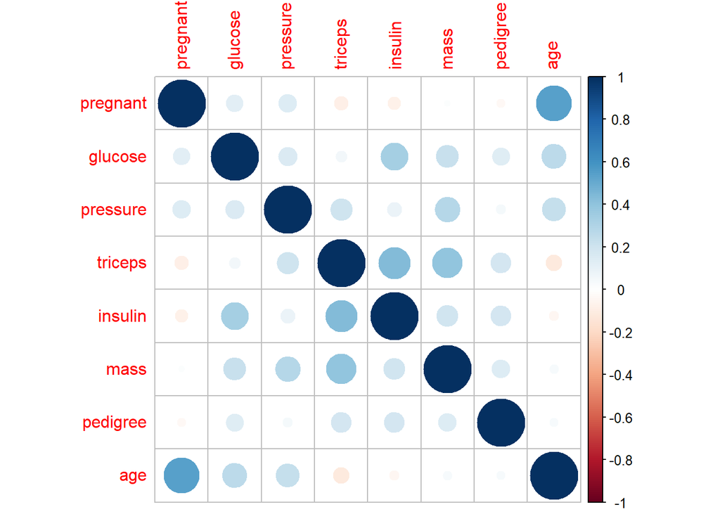

```r
library(corrplot)
correlations <- cor(PimaIndiansDiabetes[,1:8])
corrplot(correlations, method="circle")
```

## 1.2 Try linear regression

How about consider diabetes as continuous variable? And apply linear regression model?

1. We convert the factor `diabetes` to a numeric variable `diabetes_num`.
2. Apply linear regression model.
3. Plot a regression line for prediction.

**Step 1:**

```r
newDiabetes=PimaIndiansDiabetes
newDiabetes$diabetes_num=newDiabetes$diabetes
newDiabetes$diabetes_num=as.numeric(newDiabetes$diabetes_num)
newDiabetes$diabetes_num[which(newDiabetes$diabetes_num==1)]=0
newDiabetes$diabetes_num[which(newDiabetes$diabetes_num==2)]=1
```

**Step 2:**

```r
linearfit=lm(diabetes_num~glucose, data =newDiabetes)
summary(linearfit)
```

```
##
## Call:
## lm(formula = diabetes_num ~ glucose, data = newDiabetes)
##
## Residuals:
##     Min      1Q  Median      3Q     Max
## -0.8787 -0.3027 -0.1479  0.3649  1.4925
##
## Coefficients:
##               Estimate Std. Error t value Pr(>|t|)
## (Intercept) -0.4924949  0.0596125  -8.262  6.3e-16 ***
## glucose      0.0069602  0.0004767  14.600  < 2e-16 ***
## ---
## Signif. codes:  0 '***' 0.001 '**' 0.01 '*' 0.05 '.' 0.1 ' ' 1
##
## Residual standard error: 0.4221 on 766 degrees of freedom
## Multiple R-squared:  0.2177, Adjusted R-squared:  0.2167
## F-statistic: 213.2 on 1 and 766 DF,  p-value: < 2.2e-16
```

**Step 3:**

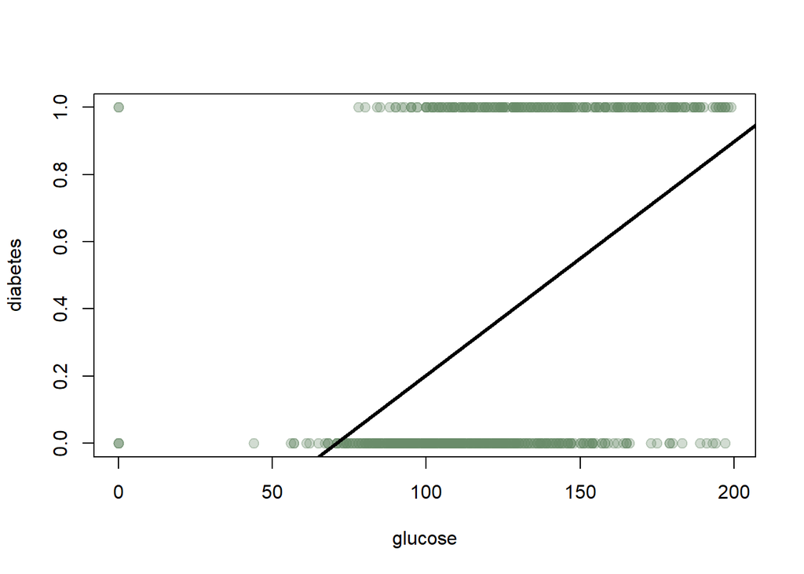

```r
library(scales)
plot(x=newDiabetes$glucose, y=newDiabetes$diabetes_num, xlab = "glucose", ylab = "diabetes",pch = 19, col=alpha("darkseagreen4", 0.3),cex=1.2)
abline(linearfit,lwd=3)
```

**Summary**: In this case, we need to predict a single value - the probability that entity is present. To do so, it will be good for us to have a function that maps any real value to value in the interval between 0 and 1. Linear regression does not work here.

## 1.3 Apply simple logistic regression

```r
logit.fit.simple <- glm(diabetes ~ glucose, data = newDiabetes, family = "binomial")
summary(logit.fit.simple)
```

```
##
## Call:
## glm(formula = diabetes ~ glucose, family = "binomial", data = newDiabetes)
##
## Deviance Residuals:
##     Min       1Q   Median       3Q      Max
## -2.1096  -0.7837  -0.5365   0.8566   3.2726
##
## Coefficients:
##              Estimate Std. Error z value Pr(>|z|)
## (Intercept) -5.350080   0.420827  -12.71   <2e-16 ***
## glucose      0.037873   0.003252   11.65   <2e-16 ***
## ---
## Signif. codes:  0 '***' 0.001 '**' 0.01 '*' 0.05 '.' 0.1 ' ' 1
##
## (Dispersion parameter for binomial family taken to be 1)
##
##     Null deviance: 993.48  on 767  degrees of freedom
## Residual deviance: 808.72  on 766  degrees of freedom
## AIC: 812.72
##
## Number of Fisher Scoring iterations: 4
```

```
## Data were 'prettified'. Consider using `terms="glucose [all]"` to get smooth plots.
```

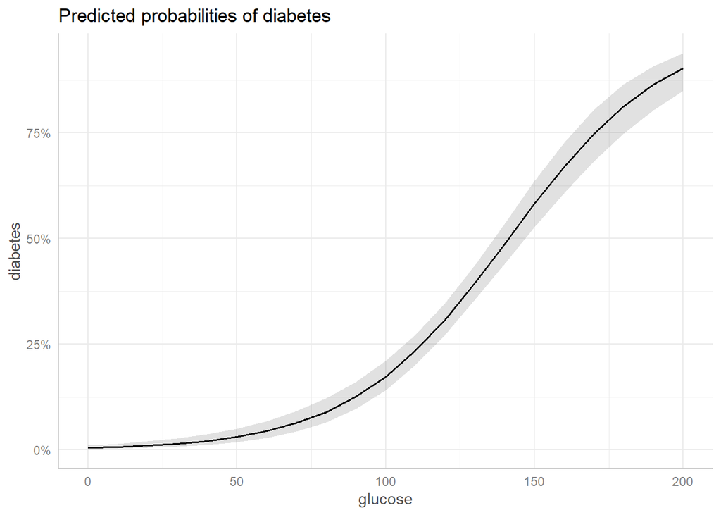

```r
library(ggeffects)
plot(ggpredict(logit.fit.simple,"glucose"))
```

# 2 Multiple Logistic Regression

In Multiple Linear Regression, we try to find the relationship between 2 or more independent variables (predictors) and the corresponding dependent variable (outcome).

## 2.1 Apply multiple logistic regression

```r
logit.fit <- glm(diabetes ~ pregnant+glucose+pressure+triceps+insulin+mass+pedigree+age, data = newDiabetes, family = "binomial")
summary(logit.fit)
```

```
##
## Call:
## glm(formula = diabetes ~ pregnant + glucose + pressure + triceps +
##     insulin + mass + pedigree + age, family = "binomial", data = newDiabetes)
##
## Deviance Residuals:
##     Min       1Q   Median       3Q      Max
## -2.5566  -0.7274  -0.4159   0.7267   2.9297
##
## Coefficients:
##               Estimate Std. Error z value Pr(>|z|)
## (Intercept) -8.4046964  0.7166359 -11.728  < 2e-16 ***
## pregnant     0.1231823  0.0320776   3.840 0.000123 ***
## glucose      0.0351637  0.0037087   9.481  < 2e-16 ***
## pressure    -0.0132955  0.0052336  -2.540 0.011072 *
## triceps      0.0006190  0.0068994   0.090 0.928515
## insulin     -0.0011917  0.0009012  -1.322 0.186065
## mass         0.0897010  0.0150876   5.945 2.76e-09 ***
## pedigree     0.9451797  0.2991475   3.160 0.001580 **
## age          0.0148690  0.0093348   1.593 0.111192
## ---
## Signif. codes:  0 '***' 0.001 '**' 0.01 '*' 0.05 '.' 0.1 ' ' 1
##
## (Dispersion parameter for binomial family taken to be 1)
##
##     Null deviance: 993.48  on 767  degrees of freedom
## Residual deviance: 723.45  on 759  degrees of freedom
## AIC: 741.45
##
## Number of Fisher Scoring iterations: 5
```

The result shows that `triceps` is not significantly associated with diabetes. We can exclude `triceps` and compare the AIC values.

```r
logit.fit_notriceps <- glm(diabetes ~ pregnant+glucose+pressure+insulin+mass+pedigree+age, data = newDiabetes, family = "binomial")
summary(logit.fit_notriceps)
```

```
##
## Call:
## glm(formula = diabetes ~ pregnant + glucose + pressure + insulin +
##     mass + pedigree + age, family = "binomial", data = newDiabetes)
##
## Deviance Residuals:
##     Min       1Q   Median       3Q      Max
## -2.5617  -0.7286  -0.4156   0.7271   2.9297
##
## Coefficients:
##               Estimate Std. Error z value Pr(>|z|)
## (Intercept) -8.4051362  0.7167033 -11.727  < 2e-16 ***
## pregnant     0.1231724  0.0320688   3.841 0.000123 ***
## glucose      0.0351123  0.0036625   9.587  < 2e-16 ***
## pressure    -0.0132136  0.0051537  -2.564 0.010350 *
## insulin     -0.0011570  0.0008142  -1.421 0.155275
## mass         0.0900886  0.0144619   6.229 4.68e-10 ***
## pedigree     0.9475954  0.2980063   3.180 0.001474 **
## age          0.0147888  0.0092897   1.592 0.111393
## ---
## Signif. codes:  0 '***' 0.001 '**' 0.01 '*' 0.05 '.' 0.1 ' ' 1
##
## (Dispersion parameter for binomial family taken to be 1)
##
##     Null deviance: 993.48  on 767  degrees of freedom
## Residual deviance: 723.45  on 760  degrees of freedom
## AIC: 739.45
##
## Number of Fisher Scoring iterations: 5
```

```
## Data were 'prettified'. Consider using `terms="glucose [all]"` to get smooth plots.
```

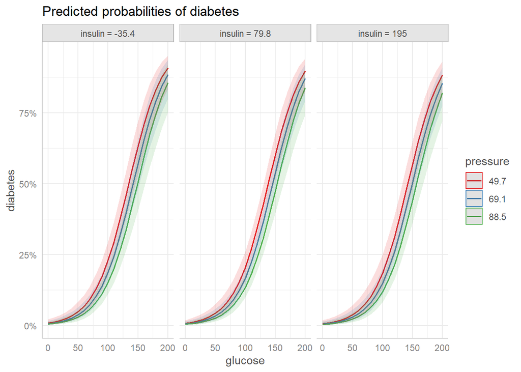

```r
library(ggeffects)
plot(ggpredict(logit.fit_notriceps,c("glucose","pressure","insulin")))
```

Practice: Try to include different predictors and check AIC values.

## 2.2 Example 1:

The in-built data set “mtcars” describes different models of a car with their various engine specifications. In “mtcars” data set, the transmission mode (automatic or manual) is described by the column am which is a binary value (0 or 1). We can create a logistic regression model between the columns “am” and 3 other columns - hp, wt and cyl.

```r
# Select some columns form mtcars.
input <- mtcars[,c("am","cyl","hp","wt")]
head(input)
```

```
##                   am cyl  hp    wt
## Mazda RX4          1   6 110 2.620
## Mazda RX4 Wag      1   6 110 2.875
## Datsun 710         1   4  93 2.320
## Hornet 4 Drive     0   6 110 3.215
## Hornet Sportabout  0   8 175 3.440
## Valiant            0   6 105 3.460
```

We use the `glm()` (generalized linear regression) function to create the regression model.

```r
logit.am = glm(formula = am ~ cyl + hp + wt, data = input, family = binomial)
```

Since we gave our model a name `logit.am`, R will not produce any output from our regression. In order to get the results we use the `summary` command:

```r
summary(logit.am)
```

```
##
## Call:
## glm(formula = am ~ cyl + hp + wt, family = binomial, data = input)
##
## Deviance Residuals:
##      Min        1Q    Median        3Q       Max
## -2.17272  -0.14907  -0.01464   0.14116   1.27641
##
## Coefficients:
##             Estimate Std. Error z value Pr(>|z|)
## (Intercept) 19.70288    8.11637   2.428   0.0152 *
## cyl          0.48760    1.07162   0.455   0.6491
## hp           0.03259    0.01886   1.728   0.0840 .
## wt          -9.14947    4.15332  -2.203   0.0276 *
## ---
## Signif. codes:  0 '***' 0.001 '**' 0.01 '*' 0.05 '.' 0.1 ' ' 1
##
## (Dispersion parameter for binomial family taken to be 1)
##
##     Null deviance: 43.2297  on 31  degrees of freedom
## Residual deviance:  9.8415  on 28  degrees of freedom
## AIC: 17.841
##
## Number of Fisher Scoring iterations: 8
```

**Result Interpretation**

- In the output above, the first thing we see is the call, this is R reminding us what the model we ran was, what options we specified, etc.
- Next we see the deviance residuals, which are a measure of model fit. This part of output shows the distribution of the deviance residuals for individual cases used in the model.
- The next part of the output shows the coefficients, their standard errors, the z-statistic (sometimes called a Wald z-statistic), and the associated p-values. **wt** is statistically significant.
- Below the table of coefficients are fit indices, including the null and deviance residuals and the AIC.

**Conclusion**

In the summary as the p-value in the last column is more than 0.05 for the variables “cyl” and “hp”, we consider them to be insignificant in contributing to the value of the variable “am”. Only weight (wt) impacts the “am” value in this regression model.

## 2.3 Example 2:

A researcher is interested in how variables, such as GRE (Graduate Record Exam scores), GPA (grade point average) and prestige of the undergraduate institution, effect admission into graduate school. The response variable, admit/don’t admit, is a binary variable.

**Description of the data**: For our data analysis below, we are going to expand on Example 2 about getting into graduate school. We have generated hypothetical data, which can be obtained from our website from within R.

```r
mydata <- read.csv("https://stats.idre.ucla.edu/stat/data/binary.csv")
head(mydata)
```

```
##   admit gre  gpa rank
## 1     0 380 3.61    3
## 2     1 660 3.67    3
## 3     1 800 4.00    1
## 4     1 640 3.19    4
## 5     0 520 2.93    4
## 6     1 760 3.00    2
```

```r
summary(mydata)
```

```
##      admit             gre             gpa             rank
##  Min.   :0.0000   Min.   :220.0   Min.   :2.260   Min.   :1.000
##  1st Qu.:0.0000   1st Qu.:520.0   1st Qu.:3.130   1st Qu.:2.000
##  Median :0.0000   Median :580.0   Median :3.395   Median :2.000
##  Mean   :0.3175   Mean   :587.7   Mean   :3.390   Mean   :2.485
##  3rd Qu.:1.0000   3rd Qu.:660.0   3rd Qu.:3.670   3rd Qu.:3.000
##  Max.   :1.0000   Max.   :800.0   Max.   :4.000   Max.   :4.000
```

```r
sapply(mydata, sd)
```

```
##       admit         gre         gpa        rank
##   0.4660867 115.5165364   0.3805668   0.9444602
```

```r
## two-way contingency table of categorical outcome and predictors we want
## to make sure there are not 0 cells
xtabs(~admit + rank, data = mydata)
```

```
##      rank
## admit  1  2  3  4
##     0 28 97 93 55
##     1 33 54 28 12
```

The code below estimates a logistic regression model using the `glm` function. First, we convert `rank` to a factor to indicate that rank should be treated as a categorical variable.

```r
mydata$rank <- factor(mydata$rank)
mylogit <- glm(admit ~ gre + gpa + rank, data = mydata, family = "binomial")
summary(mylogit)
```

```
##
## Call:
## glm(formula = admit ~ gre + gpa + rank, family = "binomial",
##     data = mydata)
##
## Deviance Residuals:
##     Min       1Q   Median       3Q      Max
## -1.6268  -0.8662  -0.6388   1.1490   2.0790
##
## Coefficients:
##              Estimate Std. Error z value Pr(>|z|)
## (Intercept) -3.989979   1.139951  -3.500 0.000465 ***
## gre          0.002264   0.001094   2.070 0.038465 *
## gpa          0.804038   0.331819   2.423 0.015388 *
## rank2       -0.675443   0.316490  -2.134 0.032829 *
## rank3       -1.340204   0.345306  -3.881 0.000104 ***
## rank4       -1.551464   0.417832  -3.713 0.000205 ***
## ---
## Signif. codes:  0 '***' 0.001 '**' 0.01 '*' 0.05 '.' 0.1 ' ' 1
##
## (Dispersion parameter for binomial family taken to be 1)
##
##     Null deviance: 499.98  on 399  degrees of freedom
## Residual deviance: 458.52  on 394  degrees of freedom
## AIC: 470.52
##
## Number of Fisher Scoring iterations: 4
```

**Result Interpretation**

- In the output above, the first thing we see is the call, this is R reminding us what the model we ran was, what options we specified, etc.
- Next we see the deviance residuals, which are a measure of model fit. This part of output shows the distribution of the deviance residuals for individual cases used in the model. Residual deviance is smaller than null deviance means our model is better than the null model.
- The next part of the output shows the coefficients, their standard errors, the z-statistic (sometimes called a Wald z-statistic), and the associated p-values. Both `gre` and `gpa` are statistically significant, as are the three terms for `rank`. The logistic regression coefficients give the change in the log odds of the outcome for a one unit increase in the predictor variable.
  - For every one unit change in `gre`, the log odds of admission (versus non-admission) increases by 0.002.
  - For a one unit increase in `gpa`, the log odds of being admitted to graduate school increases by 0.804.
  - The indicator variables for `rank` have a slightly different interpretation. For example, having attended an undergraduate institution with `rank` of 2, versus an institution with a `rank` of 1, changes the log odds of admission by -0.675.
- Below the table of coefficients are fit indices, including the null and deviance residuals and the AIC.